# Project7_NeualNetworks_BankChrun_Prediction

#### Exited Vs NumOfProducts

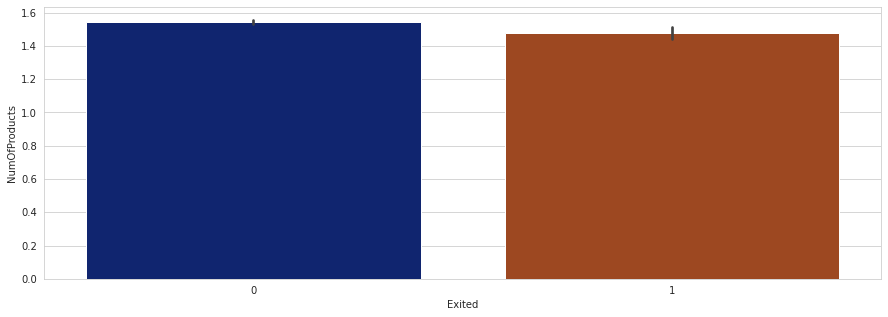

```python
plt.figure(figsize=(15,5))
sns.barplot(x="Exited", y="NumOfProducts",  data=ccardDf)
plt.show()
```

**Observations:**

- Customers having slightly less number of cards seem to have exited compared to the customers who have more number of cards.

#### Exited Vs IsActiveMember

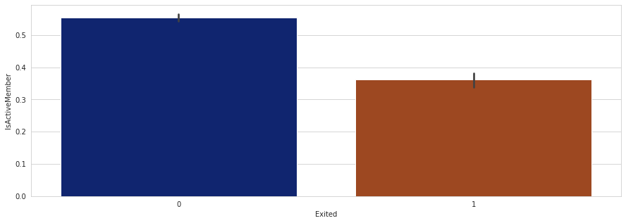

```python
plt.figure(figsize=(15,5))
sns.barplot(x="Exited", y="IsActiveMember",  data=ccardDf)
plt.show()
```

**Observations:**

- Customers who have exited the bank are not active where as the customers who have not exited are active.

#### Exited Vs EstimatedSalary

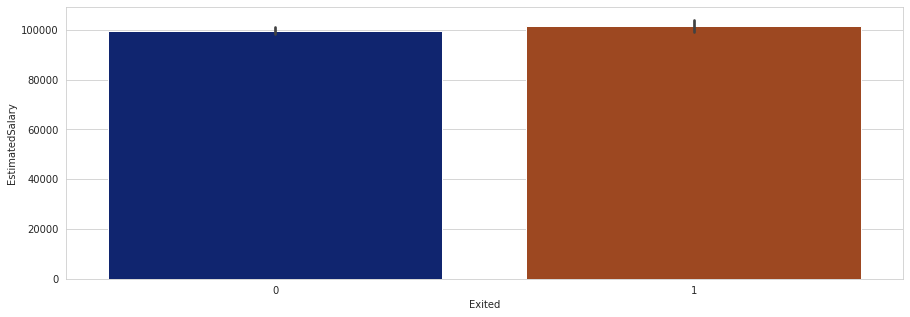

```python
plt.figure(figsize=(15,5))
sns.barplot(x="Exited", y="EstimatedSalary",  data=ccardDf)
plt.show()
```

**Observations:**

- This data seem to be evenly distributed between two different calsses, having exited customers earning slightly higher than the customers who have not exited.

#### Exited Vs Geography

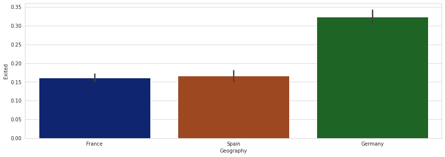

```python
plt.figure(figsize=(15,5))
sns.barplot(y="Exited", x="Geography",  data=ccardDf)
plt.show()
```

**Observations:**

- Customers from Germany have exited more than the customers from France and Spain.

#### Exited Vs Gender

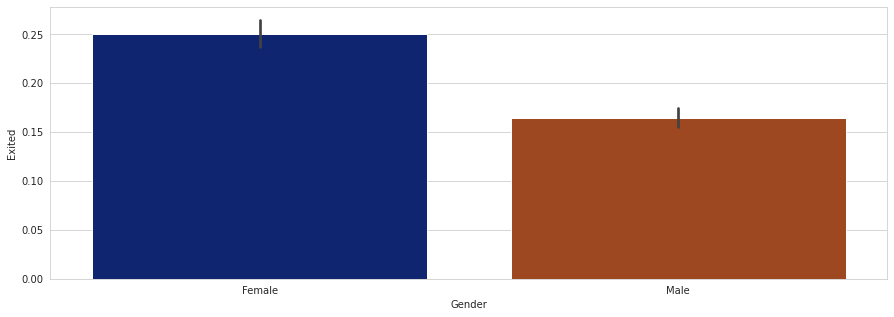

```python
plt.figure(figsize=(15,5))
sns.barplot(y="Exited", x="Gender",  data=ccardDf)
plt.show()
```

**Observations:**

- More female customers have exited than the male customers.

### Multivariate Analysis

#### Correlation Matrix

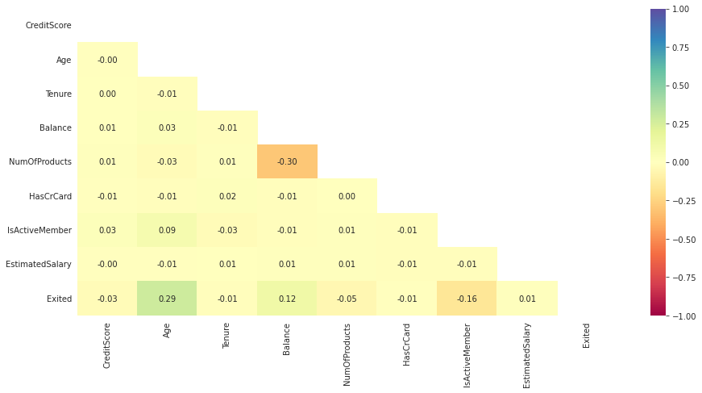

```python
plt.figure(figsize=(15, 7))
corr= ccardDf.corr()

# Getting the Upper Triangle of the co-relation matrix
matrix = np.triu(corr)

# using the upper triangle matrix as mask
sns.heatmap(corr, annot=True,vmin=-1, vmax=1, fmt=".2f", mask=matrix, cmap='Spectral')
plt.show()
```

**Observations:**

- `Age` and `Balance` have a slight positive correlation with `Exited`, where as the ressst of the variables do not show any strong correlation with each other. There is no multi-colinearity between the variables.
- I prefer to keep all the columns for my analysis as the data set has only a few variables.

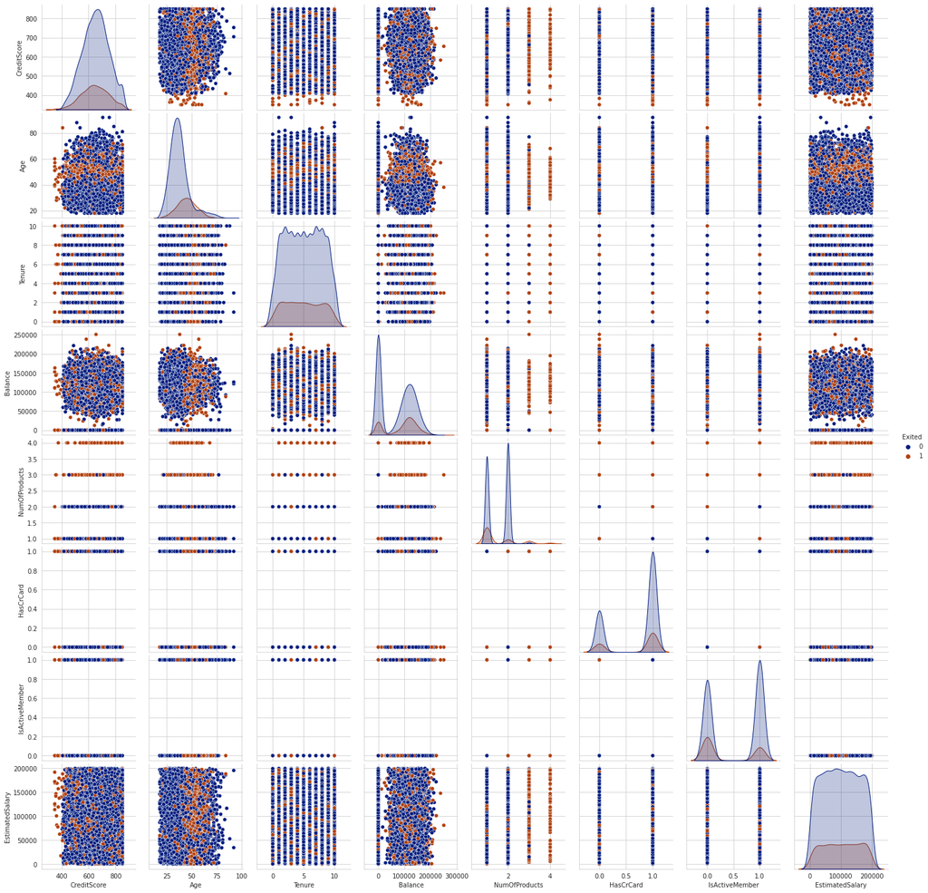

```python
sns.set_palette(sns.color_palette("dark"))
sns.pairplot(data=ccardDf[num_col], diag_kind="kde",hue = 'Exited', corner=False)
plt.show()
```

**Observations**

- From the above pair plot we can see that the Guassian curve has several humps, the data is not linear and unevenly distributed.

### Customer level analysis

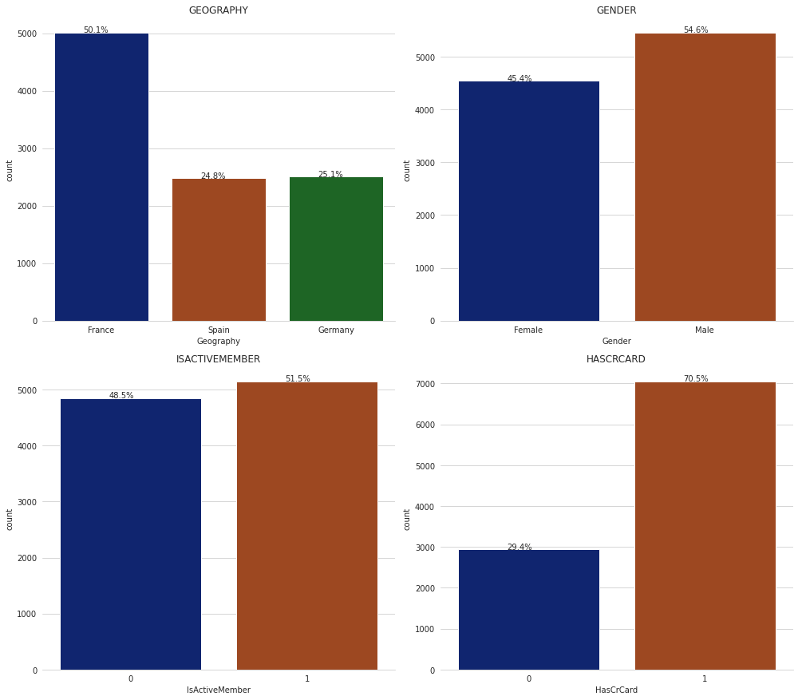

```python
title= cat_cols
category_cols= cat_cols
plt.figure(figsize=(14,24))
# sns.set_theme(style="white")
for i, variable in enumerate(category_cols):
                     plt.subplot(4,2,i+1)
                     order = ccardDf[variable].value_counts(ascending=False).index
                    #  sns.set_palette('dark')
                     ax=sns.countplot(x=ccardDf[variable], data=ccardDf)
                     sns.despine(top=True,right=True,left=True) # to remove side line from graph
                     for p in ax.patches:
                           percentage = '{:.1f}%'.format(100 * p.get_height()/len(ccardDf[variable]))
                           x = p.get_x() + p.get_width() / 2 - 0.05
                           y = p.get_y() + p.get_height()
                           plt.annotate(percentage, (x, y),ha='center')
                     plt.tight_layout()
                     plt.title(title[i].upper())
```

**Observations:**

- ~ 50.1% of the customers are from France
- ~ 25.1% of the customers are from Germany and
- ~ 24.8% of the cusomers are from Spain
- ~ 45.4% of customers are female, while
- ~ 54.6% of customers are male.
- ~ 48.5% of customers are not active.
- ~ 51.5% of them are active.
- ~70.5% of customers have card, where as 29.4% of customers do not have a credit card

#### NumOfProducts Vs Tenure Vs Exited

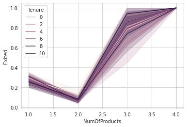

```python
sns.lineplot(x="NumOfProducts", hue="Tenure",
             y="Exited",data=ccardDf)
plt.show()
```

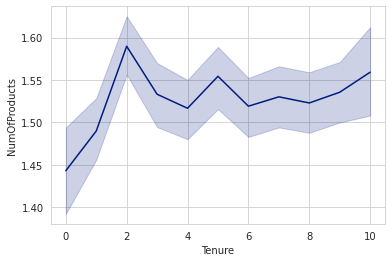

```python
sns.lineplot(y = "NumOfProducts", x = "Tenure", data = ccardDf)
plt.show()
```

**Observations:**

- Customers who have purchased more products and had a longer tenure seem to have exited more.
- Cutomers who had been with the bank for 2 years, seem to have purchased more products.
- Customers who have been with the bank for 4 to 10 years have purchased same number of products with a slight variation with customers with 5 year tenure.